# Linguagens de programação no Github

Rayssa

22 de julho de 2017

# Dados no github

Neste relatório vamos analisar uma amostra de dados da atividade global do github disponível neste link https://raw.githubusercontent.com/nazareno/fpcc2/master/datasets/github-users-committing-filetypes.csv, para respondermos algumas perguntas sobre liguagens de programação utilizadas pelos os usuários que fazem uso do github. Para iniciar esta análise precisamos escolher duas linguagens, neste caso será **Java** e **Python**.

# Descrição dos dados utilizados

Para esta análise iremos utilizar as seguintes variáveis: *file_extension* que corresponde a extensão do arquivo manipulado pelo usuário, *month_day* o dia do mês, *the_month* o mês e *the_year* o ano em que o arquivo foi criado/modificado e *users* a quantidade de pessoas que editou os arquivos.

```r
dadosGithub <- read.csv("../dados/github-users-committing-filetypes.csv")

dadosGithub$date <- paste(dadosGithub$month_day, dadosGithub$the_month, dadosGithub$the_year, sep = "-")

java <- dadosGithub %>%
  filter(file_extension == 'java') %>%
  mutate(weekday = weekdays(as.Date(date,'%d-%m-%Y')))


python <- dadosGithub %>%
  filter(file_extension == 'py') %>%
  mutate(weekday = weekdays(as.Date(date,'%d-%m-%Y')))
```

Antes de responder as perguntas desejadas, vamos observar como cada liguagem de programação se comporta em relação a sua popularidade durante os dias da semana.

## Java

```r
p = java %>%
  ggplot(aes(x = weekday,
             y = users)) +
  geom_boxplot(outlier.colour = NA) +
  geom_point(aes(text = paste("Dia da semana:", weekday, "<br>", "Popularidade:", users)),
             position = position_jitter(width = .2),
             alpha = .6,
             color = "pink") +
  labs(title = "Popularidade de Java",
         x = "Dia da semana",
         y = "Popularidade")

ggplotly(p, tooltip = "text")
```

[interactive chart not shown]

A partir do gráfico mostrado acima podemos perceber que a popularidade dessa linguagem tem como variação de 1100 a 4500 usuários por dia. Durante os fins de semana o número de usuários é bem menor e há a existência de outliers durante toda a semana, representando valores com um grande afastamento dos demais valores.

## Python

```r
p = python %>%
  ggplot(aes(x = weekday,
             y = users)) +
  geom_boxplot(outlier.colour = NA) +
  geom_point(aes(text = paste("Dia da semana:", weekday, "<br>", "Popularidade:", users)),
             position = position_jitter(width = .2),
             alpha = .6,
             color = "pink") +
  labs(title = "Popularidade de Python",
         x = "Dia da semana",
         y = "Popularidade")

ggplotly(p, tooltip = "text")
```

[interactive chart not shown]

De acordo com o gráfico acima podemos perceber que Python é um pouco mais popular que Java. A popularidade varia entre 1400 a 5600 usuários por dia. Durante os fins de semana o número de usuários também é bem menor e há a existência de outliers durante toda a semana, representando valores com um grande afastamento dos demais valores.

# Respondendo as perguntas

### 1) Para cada uma delas, há uma diferença significativa na sua popularidade durante a semana e durante o fim de semana? Essa diferença é grande?

**Linguagem de programação: Java**

```r
java_semana <- java %>%
  filter(weekday != 'sábado', weekday != 'domingo') %>%
  mutate(isFds = FALSE)

java_fds <- java %>%
  filter(weekday == 'sábado'| weekday == 'domingo') %>%
  mutate(isFds = TRUE)

javaMerge = rbind(java_fds, java_semana)
```

*Diferença entre a popularidade de usuários durante os dias de semana e nos finais de semana (JAVA)*

```r
fun.boot <- function(dados, indices) {
    d = dados[indices,]
    fds = d %>% filter(isFds == TRUE)
    fds =  median(fds$users)
    nfds = d %>% filter(isFds == FALSE)
    nfds =  median(nfds$users)
    teta = nfds / fds
    return(teta)
}

res.boot <- boot(data = javaMerge,
                 statistic = fun.boot,
                 R = 2000)

boot.ci(boot.out = res.boot, conf = 0.95, type = "bca")
```

```
## BOOTSTRAP CONFIDENCE INTERVAL CALCULATIONS
## Based on 2000 bootstrap replicates
##
## CALL :
## boot.ci(boot.out = res.boot, conf = 0.95, type = "bca")
##
## Intervals :
## Level       BCa
## 95%   ( 1.647,  1.756 )
## Calculations and Intervals on Original Scale
```

**Linguagem de programação: Python**

```r
python_semana <- python %>%
  filter(weekday != 'sábado', weekday != 'domingo') %>%
  mutate(isFds = FALSE)

python_fds <- python %>%
  filter(weekday == 'sábado'| weekday == 'domingo') %>%
  mutate(isFds = TRUE)

pythonMerge = rbind(python_fds, python_semana)
```

*Diferença entre a popularidade de usuários durante os dias de semana e nos finais de semana (PYTHON)*

```r
res.boot <- boot(data = pythonMerge,
                 statistic = fun.boot,
                 R = 2000)

boot.ci(boot.out = res.boot, conf = 0.95, type = "bca")
```

```
## BOOTSTRAP CONFIDENCE INTERVAL CALCULATIONS
## Based on 2000 bootstrap replicates
##
## CALL :
## boot.ci(boot.out = res.boot, conf = 0.95, type = "bca")
##
## Intervals :
## Level       BCa
## 95%   ( 1.783,  1.884 )
## Calculations and Intervals on Original Scale
```

### 2) Existe uma diferença significativa entre as duas linguagens na sua variação de popularidade nos finais de semana?

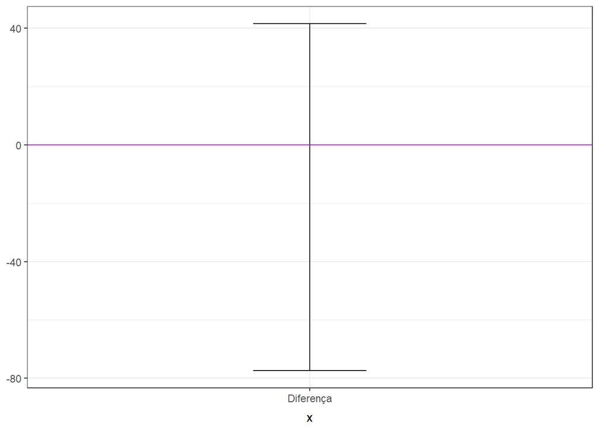

```r
median <- bootstrap2(data = (java_fds)$users,
               data2 = (python_fds)$users,
               sd)

median_ci = CI.percentile(median, probs = c(.025, .975))

data.frame(median_ci) %>%
  ggplot(aes(x = "Diferença", ymin = X2.5., ymax = X97.5.)) +
  geom_errorbar(width = .2) +
  geom_hline(yintercept = 0, colour = "purple")
```

Para responder esta pergunta precisamos utilizar o desvio padrão para cada linguagem de programação (Java e Python) e para cada final de semana e assim descobrir qual a diferença entre estes desvios, pois esta medida estatística indica o grau de variação de um conjunto de dados.

Pelo gráfico gerado acima podemos ver que a diferença do desvio padrão das linguagens está no intervalo entre -77.3790885, 41.5096286. Portanto a diferença entre a popularidade nos fins de semana para as duas linguagens pode variar entre esses valores mencionados anteriormente, como esse intervalo é composto pelo valor zero, a popularidade das duas linguagens pode ser igual.